# Peer Assessment I

First, let us load the data and necessary packages:

```r
load("ames_train.Rdata")
library(MASS)
```

```r
library(dplyr)
library(ggplot2)
```

Make a labeled histogram (with 30 bins) of the ages of the houses in the data set, and describe the distribution.

```r
# type your code for Question 1 here, and Knit
ames_age <- ames_train %>%
  mutate(age = 2019 - Year.Built) %>%
  select(age)
summary(ames_age)
```

```
##       age
##  Min.   :  9.0
##  1st Qu.: 18.0
##  Median : 44.0
##  Mean   : 46.8
##  3rd Qu.: 64.0
##  Max.   :147.0
```

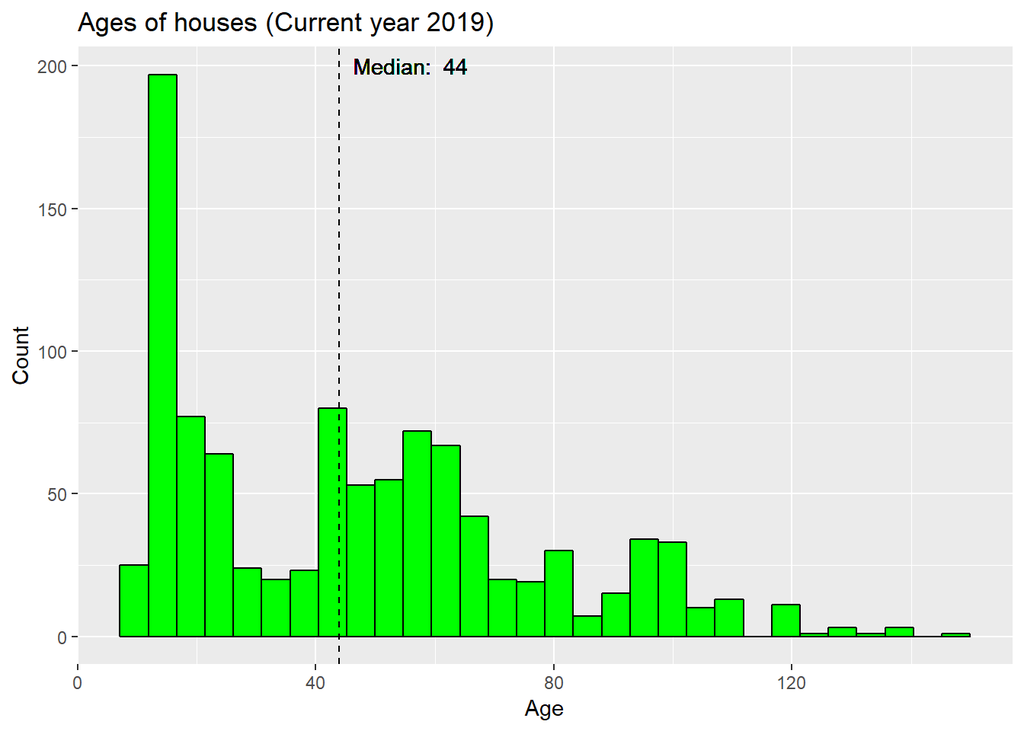

```r
ggplot(ames_age, aes(age)) +
  geom_histogram(color = "black", fill = "green", bins = 30) +
  labs(title = "Ages of houses (Current year 2019)", x = "Age", y = "Count") +
  geom_vline(aes(xintercept=median(age)), linetype = "dashed") +
  geom_text(x=median(ames_age$age) + 12, y=200, label=paste("Median: ", median(ames_age$age)))
```

The mantra in real estate is “Location, Location, Location!” Make a graphical display that relates a home price to its neighborhood in Ames, Iowa. Which summary statistics are most appropriate to use for determining the most expensive, least expensive, and most heterogeneous (having the most variation in housing price) neighborhoods? Report which neighborhoods these are based on the summary statistics of your choice. Report the value of your chosen summary statistics for these neighborhoods.

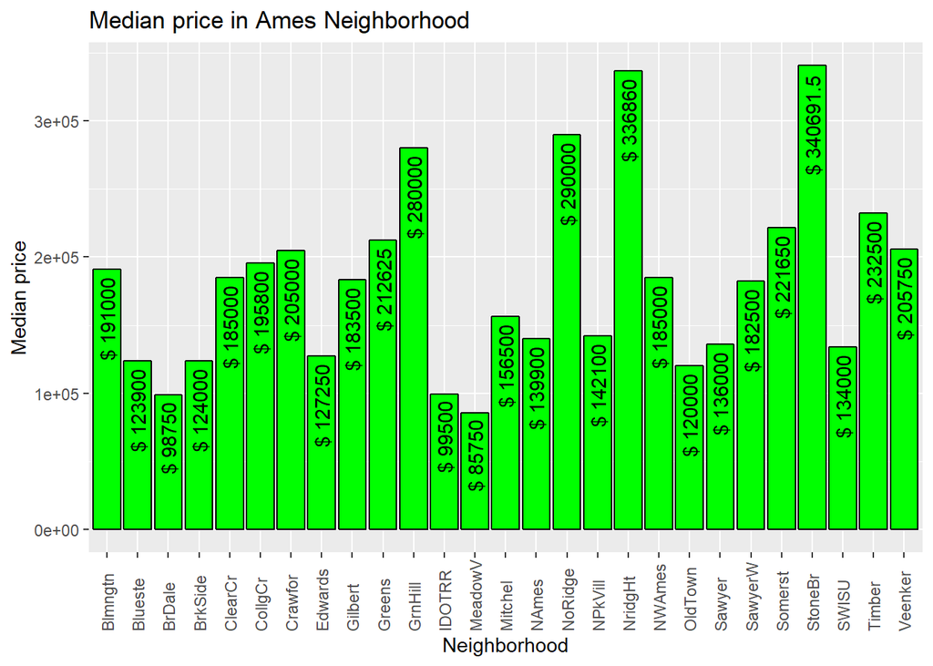

```r
# type your code for Question 2 here, and Knit
ames_price <- ames_train %>%
  group_by(Neighborhood) %>%
  summarise(Median = median(price), Sd = sd(price))

ggplot(ames_price, aes(x = Neighborhood, y = Median, label = paste("$",round(Median, 2)))) +
  geom_bar(color = "black", fill = "green", stat = "identity") +
  geom_text(angle = 90, hjust = 1.1, vjust = 0.5) +
  labs(title = "Median price in Ames Neighborhood", y = "Median price") +
  theme(axis.text.x = element_text(angle = 90, hjust = 0, vjust = 0.5))
```

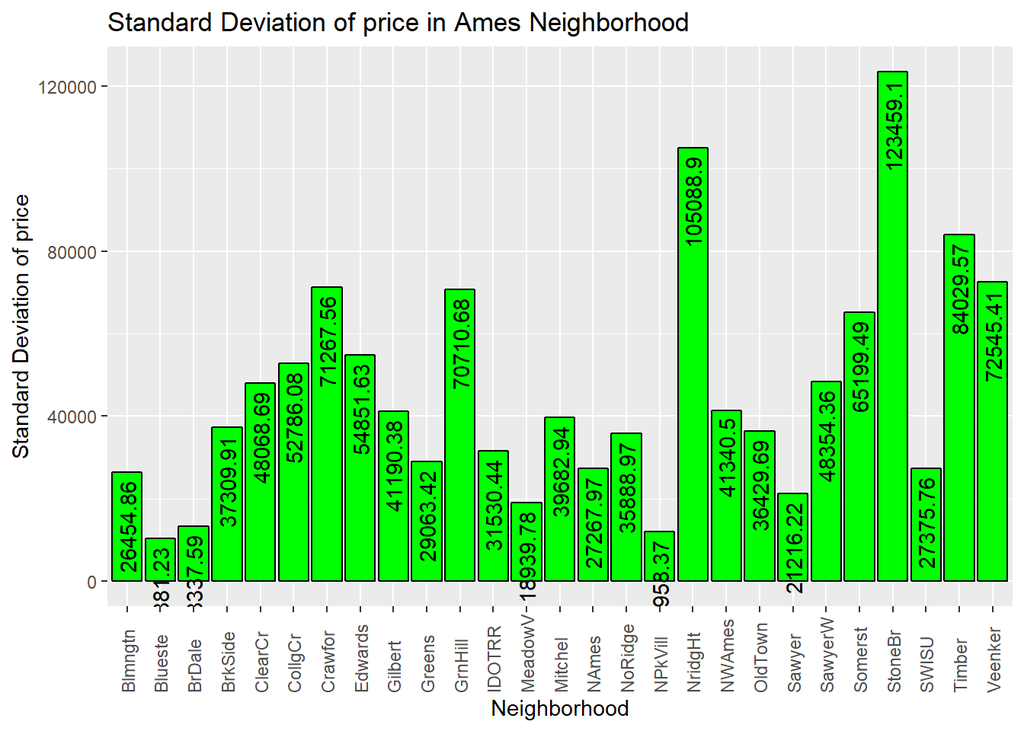

```r
ggplot(ames_price, aes(x = Neighborhood, y = Sd, label = round(Sd, 2))) +
  geom_bar(color = "black", fill = "green", stat = "identity") +
  geom_text(angle = 90, hjust = 1.1, vjust = 0.5) +
  labs(title = "Standard Deviation of price in Ames Neighborhood", y = "Standard Deviation of price") +
  theme(axis.text.x = element_text(angle = 90, hjust = 0, vjust = 0.5))
```

Median will be used to compare neighborhoods since it is more resilient to outliers than Mean.  
Heterogeneous, which is variety in values, can be determined by examing the standard deviation of price.

Based on the bar charts:

- The most expensive neighborhood is StoneBr with the Median price of $340,691.5.
- The least expensive neighborhood is MeadowV with the Median price of $85,750.0.
- The most heterogeneous is StoneBr with the standard deviation of price of 123,459.1.

Which variable has the largest number of missing values? Explain why it makes sense that there are so many missing values for this variable.

```r
# type your code for Question 3 here, and Knit
sort(sapply(ames_train, function(y) sum(length(which(is.na(y))))), decreasing= TRUE)
```

```
##         Pool.QC    Misc.Feature           Alley           Fence    Fireplace.Qu    Lot.Frontage
##             997             971             933             798             491             167
##   Garage.Yr.Blt     Garage.Qual     Garage.Cond     Garage.Type   Garage.Finish       Bsmt.Qual
##              48              47              47              46              46              21
##       Bsmt.Cond   Bsmt.Exposure  BsmtFin.Type.1  BsmtFin.Type.2    Mas.Vnr.Area    BsmtFin.SF.1
##              21              21              21              21               7               1
##    BsmtFin.SF.2     Bsmt.Unf.SF   Total.Bsmt.SF  Bsmt.Full.Bath  Bsmt.Half.Bath     Garage.Cars
##               1               1               1               1               1               1
##     Garage.Area             PID            area           price     MS.SubClass       MS.Zoning
##               1               0               0               0               0               0
##        Lot.Area          Street       Lot.Shape    Land.Contour       Utilities      Lot.Config
##               0               0               0               0               0               0
##      Land.Slope    Neighborhood     Condition.1     Condition.2       Bldg.Type     House.Style
##               0               0               0               0               0               0
##    Overall.Qual    Overall.Cond      Year.Built  Year.Remod.Add      Roof.Style       Roof.Matl
##               0               0               0               0               0               0
##    Exterior.1st    Exterior.2nd    Mas.Vnr.Type      Exter.Qual      Exter.Cond      Foundation
##               0               0               0               0               0               0
##         Heating      Heating.QC     Central.Air      Electrical     X1st.Flr.SF     X2nd.Flr.SF
##               0               0               0               0               0               0
## Low.Qual.Fin.SF       Full.Bath       Half.Bath   Bedroom.AbvGr   Kitchen.AbvGr    Kitchen.Qual
##               0               0               0               0               0               0
##   TotRms.AbvGrd      Functional      Fireplaces     Paved.Drive    Wood.Deck.SF   Open.Porch.SF
##               0               0               0               0               0               0
##  Enclosed.Porch     X3Ssn.Porch    Screen.Porch       Pool.Area        Misc.Val         Mo.Sold
##               0               0               0               0               0               0
##         Yr.Sold       Sale.Type  Sale.Condition
##               0               0               0
```

The variable with largest missing values is Pool.QC, which stands for Pool quality.  
This makes sense since the pool is not a common feature in most household.  
Checking the data, only 3 houses have Pool.Area greater than 0. All other houses don’t have pool, so Pool.QC variable can’t be filled.

We want to predict the natural log of the home prices. Candidate explanatory variables are lot size in square feet (Lot.Area), slope of property (Land.Slope), original construction date (Year.Built), remodel date (Year.Remod.Add), and the number of bedrooms above grade (Bedroom.AbvGr). Pick a model selection or model averaging method covered in the Specialization, and describe how this method works. Then, use this method to find the best multiple regression model for predicting the natural log of the home prices.

```r
library(BAS)
# type your code for Question 4 here, and Knit
bma_model <- bas.lm(log(price) ~ Lot.Area + Land.Slope + Year.Built + Year.Remod.Add + Bedroom.AbvGr,
                    data = ames_train,
                    prior = "ZS-null",
                    modelprior = uniform())
summary(bma_model)
```

```
##                P(B != 0 | Y)  model 1      model 2      model 3      model 4      model 5
## Intercept          1.0000000   1.0000   1.00000000 1.000000e+00 1.000000e+00 1.000000e+00
## Lot.Area           1.0000000   1.0000   1.00000000 1.000000e+00 1.000000e+00 0.000000e+00
## Land.SlopeMod      0.9553125   1.0000   0.00000000 1.000000e+00 0.000000e+00 1.000000e+00
## Land.SlopeSev      0.9553125   1.0000   0.00000000 1.000000e+00 0.000000e+00 1.000000e+00
## Year.Built         1.0000000   1.0000   1.00000000 1.000000e+00 1.000000e+00 1.000000e+00
## Year.Remod.Add     1.0000000   1.0000   1.00000000 1.000000e+00 1.000000e+00 1.000000e+00
## Bedroom.AbvGr      1.0000000   1.0000   1.00000000 0.000000e+00 0.000000e+00 1.000000e+00
## BF                        NA   1.0000   0.04677786 4.125993e-13 2.610887e-14 1.982959e-17
## PostProbs                 NA   0.9553   0.04470000 0.000000e+00 0.000000e+00 0.000000e+00
## R2                        NA   0.5625   0.55440000 5.338000e-01 5.254000e-01 5.244000e-01
## dim                       NA   7.0000   5.00000000 6.000000e+00 4.000000e+00 6.000000e+00
## logmarg                   NA 391.7282 388.66586363 3.632119e+02 3.604517e+02 3.532689e+02
```

```r
best_model <- predict(bma_model, estimator = 'BPM', se.fit = TRUE)
variable.names(best_model)
```

```
## [1] "Intercept"      "Lot.Area"       "Land.SlopeMod"  "Land.SlopeSev"  "Year.Built"
## [6] "Year.Remod.Add" "Bedroom.AbvGr"
```

Bayesian is chosen over Frequentist approach because it perform better on small samples. And it can reduce the variance as well as getting the credible interval of the prediction.  
And since our purpose is to predict the log of price, Bayesian Model Averaging will be the model selection method and Best Prediction Model as the estimator.  
As the result, the model will contain Lot.Area, Land.Slope, Year.Built, Year.Remod.Add and Bedroom.AbvGr.  
The coefficients of those variables:

```r
confint(coefficients(bma_model))
```

```
##                         2.5%        97.5%          beta
## Intercept       1.200098e+01 1.203570e+01  1.201847e+01
## Lot.Area        7.894648e-06 1.240181e-05  1.017677e-05
## Land.SlopeMod   0.000000e+00 2.189495e-01  1.318436e-01
## Land.SlopeSev  -7.125580e-01 0.000000e+00 -4.349927e-01
## Year.Built      5.280468e-03 6.769163e-03  6.029488e-03
## Year.Remod.Add  5.672215e-03 7.823427e-03  6.762556e-03
## Bedroom.AbvGr   6.529725e-02 1.075978e-01  8.660745e-02
## attr(,"Probability")
## [1] 0.95
## attr(,"class")
## [1] "confint.bas"
```

Which home has the largest squared residual in the previous analysis (Question 4)? Looking at all the variables in the data set, can you explain why this home stands out from the rest (what factors contribute to the high squared residual and why are those factors relevant)?

```r
# type your code for Question 5 here, and Knit
squared_residuals <- (best_model$fit - log(ames_train$price)) ** 2
squared_residuals_max_index <- which.max(squared_residuals)
print(paste("Residual: ", max(squared_residuals)))
```

```
## [1] "Residual:  4.36520482743738"
```

```r
print(paste("Predicted log price: ", best_model$fit[squared_residuals_max_index]))
```

```
## [1] "Predicted log price:  11.5456479656125"
```

```r
print(paste("Actual log price: ", log(slice(ames_train, squared_residuals_max_index)$price)))
```

```
## [1] "Actual log price:  9.45634070543332"
```

```r
slice(ames_train %>%
        mutate(log_price = log(price)) %>%
        select(PID, log_price, Lot.Area, Land.Slope, Year.Built, Year.Remod.Add, Bedroom.AbvGr) %>%
        mutate(Position = squared_residuals_max_index), squared_residuals_max_index)
```

```
## # A tibble: 1 x 8
##         PID log_price Lot.Area Land.Slope Year.Built Year.Remod.Add Bedroom.AbvGr Position
##       <int>     <dbl>    <int> <fct>           <int>          <int>         <int>    <int>
## 1 902207130      9.46     9656 Gtl              1923           1970             2      428
```

The house at position 428 (PID: 902207130) has the largest squared residual (4.37).  
One possible factor that contribute to such large error is the Lot.Area is so large for its price.  
Comparing to other houses in the dataset:

```r
print(paste("Log Price per Lot Area Square feet of house 428: ", 9.456341 / 9656))
```

```
## [1] "Log Price per Lot Area Square feet of house 428:  0.000979322804473902"
```

```r
print("Distribution of Log Price per Lot Area Square feet: ")
```

```
## [1] "Distribution of Log Price per Lot Area Square feet: "
```

```r
summary(log(ames_train$price)/ames_train$Lot.Area)
```

```
##      Min.   1st Qu.    Median      Mean   3rd Qu.      Max.
## 5.963e-05 1.043e-03 1.288e-03 1.574e-03 1.616e-03 7.949e-03
```

We can see that our house lies in the 1st quantile of the distribution.

Use the same model selection method you chose in Question 4 to again find the best multiple regression model to predict the natural log of home prices, but this time **replacing Lot.Area with log(Lot.Area)**. Do you arrive at a model including the same set of predictors?

```r
# type your code for Question 6 here, and Knit
bma_model_2 <- bas.lm(log(price) ~ log(Lot.Area) + Land.Slope + Year.Built + Year.Remod.Add + Bedroom.AbvGr,
                    data = ames_train,
                    prior = "ZS-null",
                    modelprior = uniform())
summary(bma_model_2)
```

```
##                P(B != 0 | Y)  model 1      model 2      model 3      model 4      model 5
## Intercept          1.0000000   1.0000   1.00000000 1.000000e+00 1.000000e+00 1.000000e+00
## log(Lot.Area)      1.0000000   1.0000   1.00000000 1.000000e+00 1.000000e+00 1.000000e+00
## Land.SlopeMod      0.0479760   0.0000   1.00000000 0.000000e+00 1.000000e+00 0.000000e+00
## Land.SlopeSev      0.0479760   0.0000   1.00000000 0.000000e+00 1.000000e+00 0.000000e+00
## Year.Built         1.0000000   1.0000   1.00000000 1.000000e+00 1.000000e+00 1.000000e+00
## Year.Remod.Add     1.0000000   1.0000   1.00000000 1.000000e+00 1.000000e+00 0.000000e+00
## Bedroom.AbvGr      0.9999885   1.0000   1.00000000 0.000000e+00 0.000000e+00 1.000000e+00
## BF                        NA   1.0000   0.05039408 1.191636e-05 2.064920e-07 2.615189e-33
## PostProbs                 NA   0.9520   0.04800000 0.000000e+00 0.000000e+00 0.000000e+00
## R2                        NA   0.6031   0.60560000 5.913000e-01 5.931000e-01 5.355000e-01
## dim                       NA   5.0000   7.00000000 4.000000e+00 6.000000e+00 4.000000e+00
## logmarg                   NA 446.1644 443.17649993 4.348268e+02 4.307714e+02 3.711404e+02
```

```r
best_model_2 <- predict(bma_model_2, estimator = 'BPM', se.fit = TRUE)
variable.names(best_model_2)
```

```
## [1] "Intercept"      "log(Lot.Area)"  "Year.Built"     "Year.Remod.Add" "Bedroom.AbvGr"
```

Replacing Lot.Area with log(Lot.Area) resulted in a different model, with Land.Slope variable is not a predictor anymore.  
The new model contains Lot.Area, Year.Built, Year.Remod.Add and Bedroom.AbvGr.

Do you think it is better to log transform Lot.Area, in terms of assumptions for linear regression? Make graphs of the predicted values of log home price versus the true values of log home price for the regression models selected for Lot.Area and log(Lot.Area). Referencing these two plots, provide a written support that includes a quantitative justification for your answer in the first part of question 7.

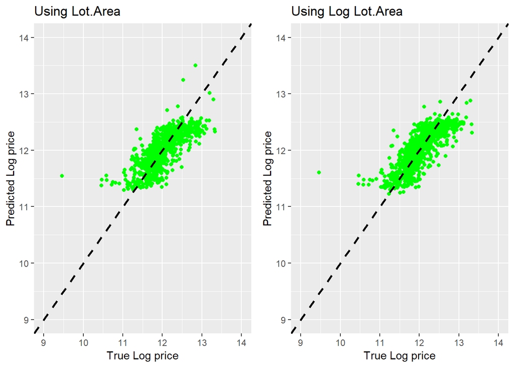

```r
# type your code for Question 7 here, and Knit
true_vs_predicted_using_area <- as.data.frame(cbind(log(ames_train$price), best_model$fit))
plot_area <- ggplot(true_vs_predicted_using_area, aes(x = log(ames_train$price), y = best_model$fit)) +
  geom_point(color = "green") +
  labs(title = "Using Lot.Area", x = "True Log price", y = "Predicted Log price") +
  geom_abline(intercept = 0, slope = 1, size = 1, linetype = "dashed") +
  xlim(9, 14) + ylim(9, 14)

true_vs_predicted_using_log_area <- as.data.frame(cbind(log(ames_train$price), best_model_2$fit))
plot_log_area <- ggplot(true_vs_predicted_using_area, aes(x = log(ames_train$price), y = best_model_2$fit)) +
  geom_point(color = "green") +
  labs(title = "Using Log Lot.Area", x = "True Log price", y = "Predicted Log price") +
  geom_abline(intercept = 0, slope = 1, size = 1, linetype = "dashed") +
  xlim(9, 14) + ylim(9, 14)

gridExtra::grid.arrange(plot_area, plot_log_area, ncol=2)
```

Based on the graphs, using Log of Lot.Area doesn’t seem to help much:

- The outlier which we considered in Q5 still exist.
- The residuals doesn’t seem to be reduced much.

Although using Log of Lot.Area doesn’t improve the prediction significantly, the second model, which log the Lot.Area, is the better model.